# Booster et al.

Review of the literature on COVID-19 vaccine boosters. DEMO ARTICLE NOT FOR CLINICAL USE.

Chaichontat Sriworarat (Johns Hopkins University)  
2021-11-08

> To boost or not to boost. That is the question.

## The Waning Problem

Recent reports have indicated potential “waning” of vaccine protection against COVID-19, especially in BNT162b2 [1].

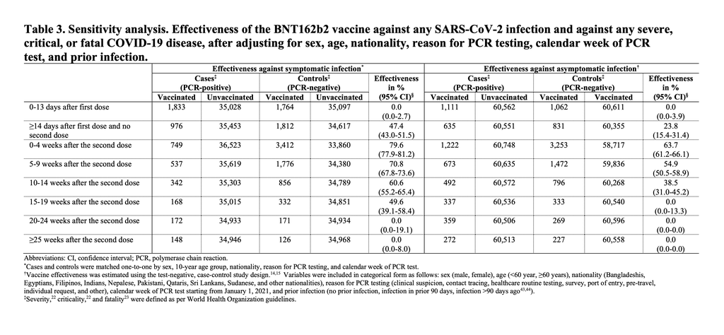

This is in tandem with reports of declining neutralizing titer.

### Vaccine Efficacy

All of the reports so far have suggested that major vaccine efficacy decreases occur only in protection against infection, both asymptomatic and symptomatic, but not for hospitalization and death.

## Are boosters the solution?

The answer depends strongly on our end goal and limits in vaccine supply.

### Constrained Supply

Ethics direct that we should direct the vaccines toward the people who would benefit the most, that is, those in middle- and low-income countries.

### Unconstrained Supply

In this case, we need to conduct a cost-benefit analysis, especially in light of reports of myocarditis in young adults [2]. Can the potential increase in protection against “mild” infection outweigh the risks?

1.

Chemaitelly, H. *et al.* Waning of BNT162b2 vaccine protection against SARS-CoV-2 infection in Qatar. 2021.08.25.21262584 (2021) doi:10.1101/2021.08.25.21262584.

2.

Verma, A. K., Lavine, K. J. & Lin, C.-Y. [Myocarditis after Covid-19 mRNA Vaccination](https://doi.org/10.1056/NEJMc2109975). *N. Engl. J. Med.* **0**, null (2021)

**Case report of two adult patients with fulminant myocarditis that had happened within 2 weeks of vaccination with mRNA vaccines.**